# Inspect cross contamination in A1 data

Michael McLaren

2020-08-01

Goal: Use the positive controls to inspect the extent of cross contamination. This analyses was conducted in 2020-02, and was updated on 2020-08-01 to use the new results files and create an html report.

## Setup

```r
library(speedyseq)
library(tidyverse)
library(here)
library(cowplot)
library(ggridges)
theme_set(theme_minimal_grid(12))
```

```r
my_psmelt <- function(physeq) {
  speedyseq::psmelt(physeq) %>%
    as_tibble %>%
    rename(taxon = OTU, sample = Sample, abundance = Abundance)
}
as_tibble.phyloseq <- function(x) {
  x %>% my_psmelt
}
as_tibble.sample_data <- function(x) {
  x %>% as("data.frame") %>% as_tibble(rownames = "sample")
}
as_tibble.taxonomyTable <- function(x) {
  x %>% as("matrix") %>% as_tibble(rownames = "taxon")
}
as_tibble.XStringSet <- function(x) {
  x %>% as.character %>% enframe("taxon", "sequence")
}
```

Import into phyloseq.

```r
ps <- readRDS(here("results/a1/a1-phyloseq-silva-v138.Rds")) %>%
  print
```

```
## phyloseq-class experiment-level object
## otu_table()   OTU Table:         [ 367 taxa and 96 samples ]
## sample_data() Sample Data:       [ 96 samples by 22 sample variables ]
## tax_table()   Taxonomy Table:    [ 367 taxa by 7 taxonomic ranks ]
## refseq()      DNAStringSet:      [ 367 reference sequences ]
```

```r
sample_data(ps) <- sample_data(ps) %>%
  transform(extraction_batch = as.factor(extraction_batch))
```

```r
pstb <- ps %>% as_tibble
tax <- tax_table(ps) %>% as_tibble
ref <- refseq(ps) %>% as_tibble
sam <- sample_data(ps) %>% as_tibble
```

## T. mobilis spatial pattern

```r
tmob <- pstb %>%
  mutate_by(sample, proportion = close_elts(abundance)) %>%
  filter(genus == "Thioflavicoccus")

a <- tax %>%
  filter(genus == "Thioflavicoccus") %>%
  left_join(ref, by = "taxon")
a %>% pull(sequence)
```

```
## [1] "TACGGAGGGTGCAAGCGTTAATCGGAATCACTGGGCGTAAAGGGCGCGTAGGCGGCGAGG…"
## [2] "TACGGAGGGTGCAAGCGTTAATCGGAATCACTGGGCGTAAAGGGCGCGTAGGCGGCGAGG…"
```

ASV301 has a single mismatch from ASV11. It appears in only two reads, and so is most likely sequence error.

```r
tmob %>%
  group_by(taxon) %>%
  summarize_at("abundance", sum)
```

```
## # A tibble: 2 x 2
##   taxon     abundance
##   <chr>         <int>
## 1 A1_ASV11     305306
## 2 A1_ASV301         2
```

Future: can just filter out ASV301.

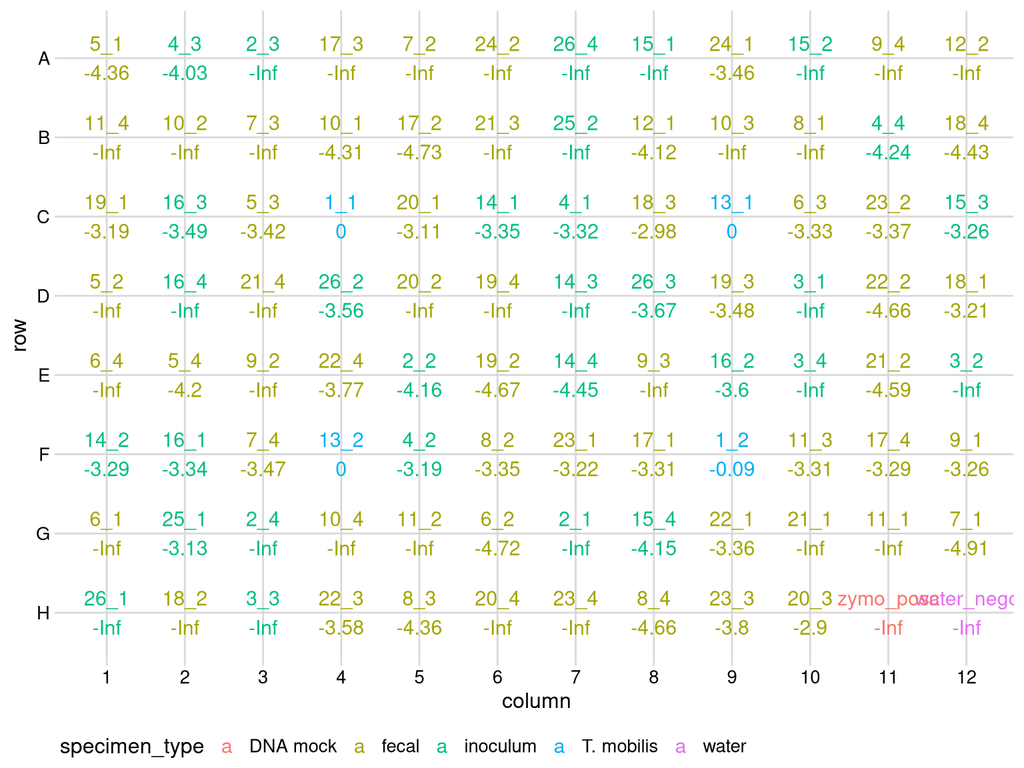

```r
tmob %>%
  filter(species == "mobilis") %>%
  mutate(
    row = fct_rev(row),
    label =  paste(str_replace(sample, "A1_", ""),
      round(log10(proportion), 2), sep = "\n")
    ) %>%
  ggplot(aes(y = row, x = column, color = specimen_type)) +
  geom_text(aes(label = label), size = 4) +
  theme(legend.position = "bottom")
```

Create heatmap

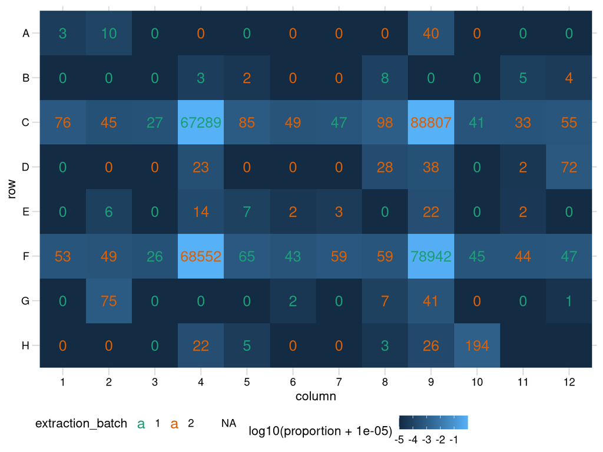

```r
tmob %>%
  filter(species == "mobilis") %>%
  mutate(
    row = fct_rev(row),
    ) %>%
  ggplot(aes(y = row, x = column, fill = log10(proportion + 1e-5))) +
  geom_raster() +
  geom_text(aes(label = abundance, color = extraction_batch), size = 5) +
  scale_color_brewer(type = "qual", palette = 2) +
  theme(legend.position = "bottom")
```

```r
tmob %>%
  filter(proportion > 0) %>%
  pull(proportion) %>%
  summary
```

```
##      Min.   1st Qu.    Median      Mean   3rd Qu.      Max.
## 0.0000123 0.0000603 0.0003365 0.0692998 0.0005304 0.9957393
```

### Figures to discuss

First, wanted to check the cross-sample contamination levels

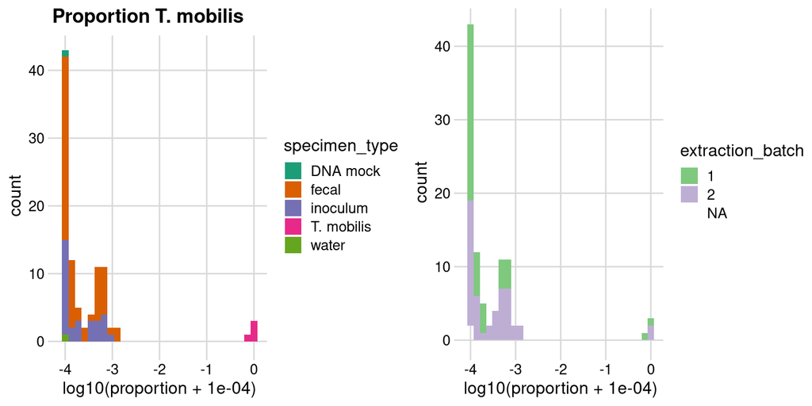

```r
p1 <- tmob %>%
  filter(species == "mobilis") %>%
  ggplot(aes(log10(proportion + 1e-4), fill = specimen_type)) +
  scale_fill_brewer(type = "qual", palette = 2) +
  labs(title = "Proportion T. mobilis") +
  geom_histogram()
p2 <- tmob %>%
  filter(species == "mobilis") %>%
  ggplot(aes(log10(proportion + 1e-4), fill = extraction_batch)) +
  scale_fill_brewer(type = "qual", palette = 1) +
  geom_histogram()
plot_grid(p1, p2)
```

```r
ggsave(
  here("results/figures", "2020-02-10-t-mobilis-contam-histogram.pdf"),
  width = 8,
  height = 4
)
```

Then wanted to see if there was a spatial pattern. Plate design:

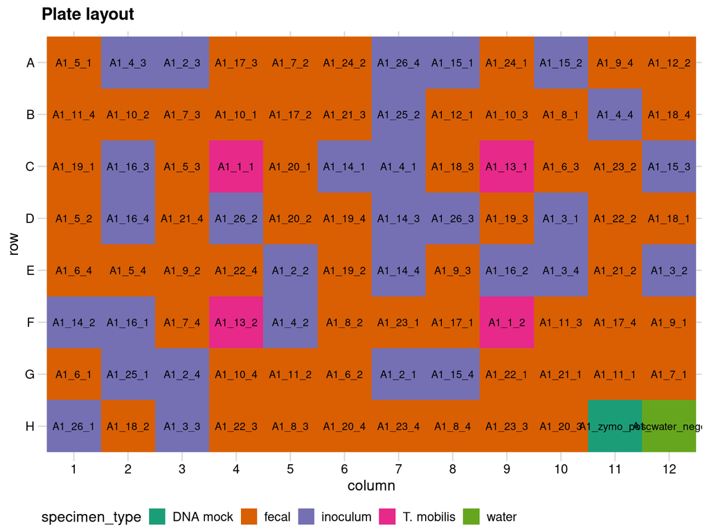

```r
sam %>%
  filter(!is.na(specimen_type)) %>%
  mutate(
    row = fct_rev(row),
    ) %>%
  ggplot(aes(y = row, x = column, fill = specimen_type)) +
  geom_raster() +
  # geom_text(aes(label = extraction_batch), size = 5) +
  geom_text(aes(label = sample), size = 3) +
  scale_fill_brewer(type = "qual", palette = 2) +
  labs(title = "Plate layout") +
  theme(
    legend.position = "bottom"
    )
```

```r
ggsave(
  here("results/figures", "2020-02-10-plate-layout.pdf"),
  width = 8,
  height = 6
)
```

And heatmap of T. mobilis proportion,

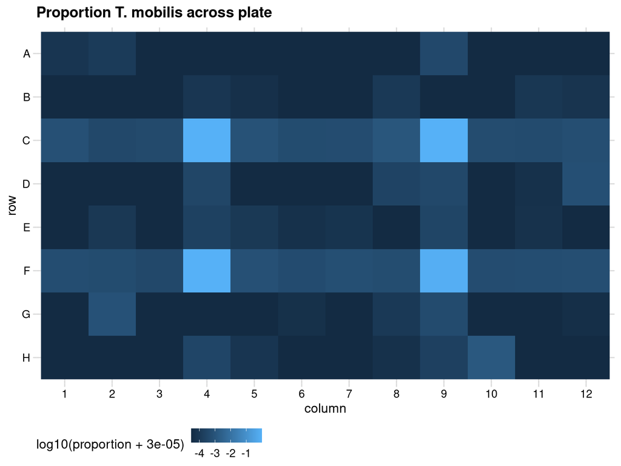

```r
tmob %>%
  filter(species == "mobilis") %>%
  mutate(
    row = fct_rev(row),
    ) %>%
  ggplot(aes(y = row, x = column, fill = log10(proportion + 3e-5))) +
  geom_raster() +
  labs(title = "Proportion T. mobilis across plate") +
  theme(
    legend.position = "bottom"
    )
```

```r
ggsave(
  here("results/figures", "2020-02-10-t-mobilis-contam-across-plate.pdf"),
  width = 8,
  height = 6
)
```

So not the pattern I might have expected, of a spatial proximity; instead, the pattern seems to mainly be of contamination across the row. Not sure what would cause this and whether it is more likely to be on their end or our end. It does tell us that we do have to be cautious in interpretting proportions <1e-2.

## Contamimation from zymo

find the zymo-only asvs

```r
ps.zymo <- prune_samples("A1_zymo_posc", ps) %>%
  filter_taxa2(~sum(.)>500)
tax_table(ps.zymo)[,1:6]
```

```
## Taxonomy Table:     [9 taxa by 6 taxonomic ranks]:
##          kingdom    phylum           class
## A1_ASV2  "Bacteria" "Proteobacteria" "Gammaproteobacteria"
## A1_ASV6  "Bacteria" "Firmicutes"     "Bacilli"
## A1_ASV21 "Bacteria" "Firmicutes"     "Bacilli"
## A1_ASV22 "Bacteria" "Firmicutes"     "Bacilli"
## A1_ASV23 "Bacteria" "Proteobacteria" "Gammaproteobacteria"
## A1_ASV25 "Bacteria" "Firmicutes"     "Bacilli"
## A1_ASV27 "Bacteria" "Firmicutes"     "Bacilli"
## A1_ASV28 "Bacteria" "Proteobacteria" "Gammaproteobacteria"
## A1_ASV29 "Bacteria" "Proteobacteria" "Gammaproteobacteria"
##          order              family               genus
## A1_ASV2  "Enterobacterales" "Enterobacteriaceae" "Escherichia/Shigella"
## A1_ASV6  "Staphylococcales" "Staphylococcaceae"  "Staphylococcus"
## A1_ASV21 "Lactobacillales"  "Lactobacillaceae"   "Lactobacillus"
## A1_ASV22 "Bacillales"       "Bacillaceae"        "Bacillus"
## A1_ASV23 "Enterobacterales" "Enterobacteriaceae" "Salmonella"
## A1_ASV25 "Lactobacillales"  "Listeriaceae"       "Listeria"
## A1_ASV27 "Lactobacillales"  "Enterococcaceae"    "Enterococcus"
## A1_ASV28 "Pseudomonadales"  "Pseudomonadaceae"   "Pseudomonas"
## A1_ASV29 "Enterobacterales" "Enterobacteriaceae" "Salmonella"
```

```r
taxa_sums(ps.zymo)
```

```
##  A1_ASV2  A1_ASV6 A1_ASV21 A1_ASV22 A1_ASV23 A1_ASV25 A1_ASV27 A1_ASV28
##    11809    18326    15574    15526    14786    12778     9191     8502
## A1_ASV29
##     2452
```

```r
zymo_taxa <- taxa_names(ps.zymo)
ps.inoc <- ps %>%
  subset_samples(specimen_type == "inoculum") %>%
  filter_taxa2(~sum(.)>1000)
tax_table(ps.inoc)[,4:6]
```

```
## Taxonomy Table:     [18 taxa by 3 taxonomic ranks]:
##          order                family               genus
## A1_ASV1  "Bacteroidales"      "Bacteroidaceae"     "Bacteroides"
## A1_ASV2  "Enterobacterales"   "Enterobacteriaceae" "Escherichia/Shigella"
## A1_ASV3  "Verrucomicrobiales" "Akkermansiaceae"    "Akkermansia"
## A1_ASV4  "Bacteroidales"      "Bacteroidaceae"     "Bacteroides"
## A1_ASV5  "Bacteroidales"      "Bacteroidaceae"     "Bacteroides"
## A1_ASV6  "Staphylococcales"   "Staphylococcaceae"  "Staphylococcus"
## A1_ASV7  "Lachnospirales"     "Lachnospiraceae"    "Lachnoclostridium"
## A1_ASV8  "Bacteroidales"      "Bacteroidaceae"     "Bacteroides"
## A1_ASV9  "Lachnospirales"     "Lachnospiraceae"    "Roseburia"
## A1_ASV10 "Bacteroidales"      "Bacteroidaceae"     "Bacteroides"
## A1_ASV12 "Oscillospirales"    "Ruminococcaceae"    "Faecalibacterium"
## A1_ASV13 "Bacillales"         "Bacillaceae"        "Bacillus"
## A1_ASV15 "Coriobacteriales"   "Coriobacteriaceae"  "Collinsella"
## A1_ASV16 "Lachnospirales"     "Lachnospiraceae"    "Marvinbryantia"
## A1_ASV17 "Lachnospirales"     "Lachnospiraceae"    "Roseburia"
## A1_ASV18 "Lachnospirales"     "Lachnospiraceae"    "Agathobacter"
## A1_ASV24 "Bacillales"         "Bacillaceae"        "Bacillus"
## A1_ASV26 "Bacillales"         "Bacillaceae"        "Bacillus"
```

```r
taxa_sums(ps.inoc)
```

```
##  A1_ASV1  A1_ASV2  A1_ASV3  A1_ASV4  A1_ASV5  A1_ASV6  A1_ASV7  A1_ASV8
##    35167   759865   181042   137149   126390   708938   222337     8792
##  A1_ASV9 A1_ASV10 A1_ASV12 A1_ASV13 A1_ASV15 A1_ASV16 A1_ASV17 A1_ASV18
##   204285    75971   232970   209207   104693    53457    39670    15874
## A1_ASV24 A1_ASV26
##    13138    12515
```

```r
taxa_sums(ps.zymo)
```

```
##  A1_ASV2  A1_ASV6 A1_ASV21 A1_ASV22 A1_ASV23 A1_ASV25 A1_ASV27 A1_ASV28
##    11809    18326    15574    15526    14786    12778     9191     8502
## A1_ASV29
##     2452
```

```r
zymo_only_taxa <- setdiff(taxa_names(ps.zymo), taxa_names(ps.inoc))
overlap_taxa <- intersect(taxa_names(ps.zymo), taxa_names(ps.inoc))
tax %>% filter(taxon %in% overlap_taxa)
```

```
## # A tibble: 2 x 8
##   taxon  kingdom  phylum   class   order  family  genus   species
##   <chr>  <chr>    <chr>    <chr>   <chr>  <chr>   <chr>   <chr>
## 1 A1_AS… Bacteria Proteob… Gammap… Enter… Entero… Escher… <NA>
## 2 A1_AS… Bacteria Firmicu… Bacilli Staph… Staphy… Staphy… argenteus/aureu…
```

Note, Staph shouldn’t be there - may be a lab contamination of the inoculum.

Get the proportion of the zymo only taxa for each sample

```r
zymo <- ps %>%
  transform_sample_counts(close_elts) %>%
  prune_taxa(zymo_only_taxa, .) %>%
  merge_taxa(zymo_only_taxa) %>%
  as_tibble %>%
  rename(proportion = abundance)
```

make a heatmap

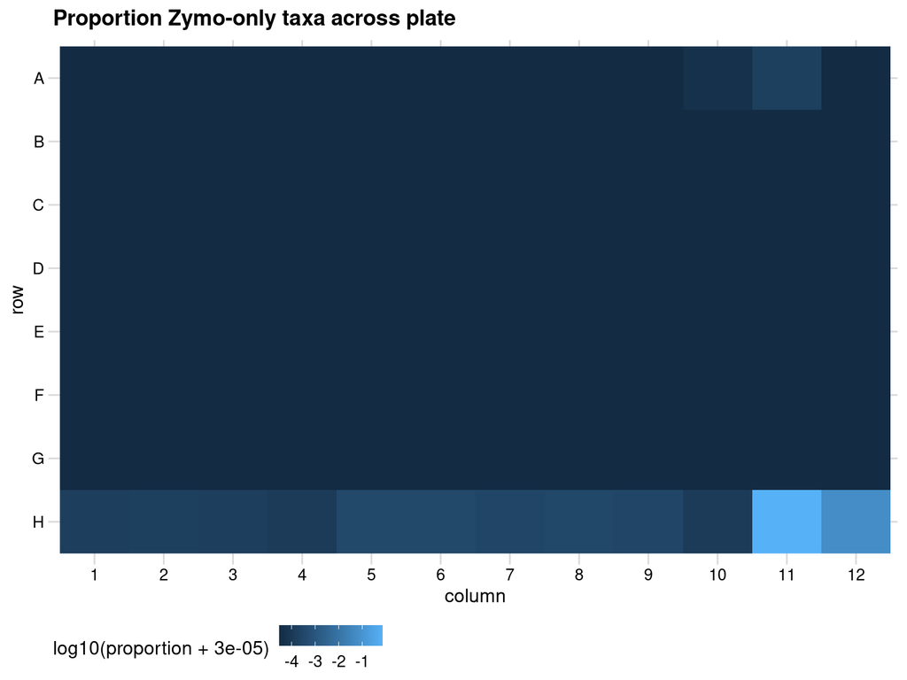

```r
zymo %>%
  mutate(
    row = fct_rev(row),
    ) %>%
  ggplot(aes(y = row, x = column, fill = log10(proportion + 3e-5))) +
  geom_raster() +
  labs(title = "Proportion Zymo-only taxa across plate") +
  theme(
    legend.position = "bottom"
    )
```

```r
ggsave(
  here("results/figures", "2020-02-10-zymo-contam-across-plate.pdf"),
  width = 8,
  height = 6
)
```